# Bike-Share Case Study

Hadeer

2026-01-13

[figure not shown]

### About The Company

In 2016, Cyclistic launched a successful bike-share offering. Since then, the program has grown to a fleet of 5,824 bicycles that are geotracked and locked into a network of 692 stations across Chicago. The bikes can be unlocked from one station and returned to any other station in the system anytime.

Until now, Cyclistic’s marketing strategy relied on building general awareness and appealing to broad consumer segments. One approach that helped make these things possible was the flexibility of its pricing plans: single-ride passes, full-day passes, and annual memberships.Customers who purchase single-ride or full-day passes are referred to as casual riders.Customers who purchase annual memberships are Cyclistic members.

Cyclistic’s finance analysts have concluded that annual members are much more profitable than casual riders. Although the pricing flexibility helps Cyclistic attract more customers, Moreno believes that maximizing the number of annual members will be key to future growth. Rather than creating a marketing campaign that targets all-new customers, Moreno believes there is a solid opportunity to convert casual riders into members. She notes that casual riders are already aware of the Cyclistic program and have chosen Cyclistic for their mobility needs.

### 1. Ask

#### 1.1 Questions

1. How do annual members and casual riders use Cyclistic bikes differently?
2. Why would casual riders buy Cyclistic annual memberships?
3. How can Cyclistic use digital media to influence casual riders to become members?

#### 1.2 Business Task

Design marketing strategies aimed at converting casual riders into annual members. In order to do that, however, the team needs to better understand how annual members and casual riders differ, why casual riders would buy a membership, and how digital media could affect their marketing tactics. Moreno and her team are interested in analyzing the Cyclistic historical bike trip data to identify trends.

#### 1.3 Characters and teams

- **Cyclistic:** A bike-share program that features more than 5,800 bicycles and 600 docking stations. Cyclistic sets itself apart by also offering reclining bikes, hand tricycles, and cargo bikes, making bike-share more inclusive to people with disabilities and riders who can’t use a standard two-wheeled bike. The majority of riders opt for traditional bikes; about 8% of riders use the assistive options. Cyclistic users are more likely to ride for leisure, but about 30% use the bikes to commute to work each day.
- **Lily Moreno:** The director of marketing and your manager. Moreno is responsible for the development of campaigns and initiatives to promote the bike-share program. These may include email, social media, and other channels.
- **Cyclistic marketing analytics team:** A team of data analysts who are responsible for collecting, analyzing, and reporting data that helps guide Cyclistic marketing strategy. You joined this team six months ago and have been busy learning about Cyclistic’s mission and business goals—as well as how you, as a junior data analyst, can help Cyclistic achieve them.
- **Cyclistic executive team:** The notoriously detail-oriented executive team will decide whether to approve the recommended marketing program.

### 2. Prepare

#### 2.1 About the Data

The data has been made available by Motivate International Inc. under this license. This is public data that can use to explore how different customer types are using Cyclistic bikes.

#### 2.2 How the Data Organized

There are 2 CSV files each one represents information about the ride id, started date and time, ended date and time, start and end station names, and the member types.

#### 2.3 Data Credibility

The data contains data for 2019 and 2020 only not up to date so I will consider the data not match the ROCCC standards.

### 3. Process

#### 3.1 The Analysis Tool

I will use the R tool for my analysis because the data is big and R can help me analyze, clean, visualize and present my findings with stakeholders.

#### 3.2 Install the Reqired Packages

```r
library(tidyverse)
library(janitor)
library(skimr)
library(here)
library(lubridate)
```

#### 3.2 Uploading the Files

```r
trips_2019 <- read.csv(here("Data", "Divvy_Trips_2019_Q1.csv"))
trips_2020 <- read.csv(here("Data","Divvy_Trips_2020_Q1.csv"))
```

#### 3.3 Study the Data

```r
glimpse(trips_2019)
```

```
## Rows: 365,069
## Columns: 12
## $ trip_id           <int> 21742443, 21742444, 21742445, 21742446, 21742447, 21…
## $ start_time        <chr> "2019-01-01 0:04:37", "2019-01-01 0:08:13", "2019-01…
## $ end_time          <chr> "2019-01-01 0:11:07", "2019-01-01 0:15:34", "2019-01…
## $ bikeid            <int> 2167, 4386, 1524, 252, 1170, 2437, 2708, 2796, 6205,…
## $ tripduration      <chr> "390", "441", "829", "1,783.00", "364", "216", "177"…
## $ from_station_id   <int> 199, 44, 15, 123, 173, 98, 98, 211, 150, 268, 299, 2…
## $ from_station_name <chr> "Wabash Ave & Grand Ave", "State St & Randolph St", …
## $ to_station_id     <int> 84, 624, 644, 176, 35, 49, 49, 142, 148, 141, 295, 4…
## $ to_station_name   <chr> "Milwaukee Ave & Grand Ave", "Dearborn St & Van Bure…
## $ usertype          <chr> "Subscriber", "Subscriber", "Subscriber", "Subscribe…
## $ gender            <chr> "Male", "Female", "Female", "Male", "Male", "Female"…
## $ birthyear         <int> 1989, 1990, 1994, 1993, 1994, 1983, 1984, 1990, 1995…
```

```r
glimpse(trips_2020)
```

```
## Rows: 426,887
## Columns: 13
## $ ride_id            <chr> "EACB19130B0CDA4A", "8FED874C809DC021", "789F3C21E4…
## $ rideable_type      <chr> "docked_bike", "docked_bike", "docked_bike", "docke…
## $ started_at         <chr> "2020-01-21 20:06:59", "2020-01-30 14:22:39", "2020…
## $ ended_at           <chr> "2020-01-21 20:14:30", "2020-01-30 14:26:22", "2020…
## $ start_station_name <chr> "Western Ave & Leland Ave", "Clark St & Montrose Av…
## $ start_station_id   <int> 239, 234, 296, 51, 66, 212, 96, 96, 212, 38, 117, 1…
## $ end_station_name   <chr> "Clark St & Leland Ave", "Southport Ave & Irving Pa…
## $ end_station_id     <int> 326, 318, 117, 24, 212, 96, 212, 212, 96, 100, 632,…
## $ start_lat          <dbl> 41.9665, 41.9616, 41.9401, 41.8846, 41.8856, 41.889…
## $ start_lng          <dbl> -87.6884, -87.6660, -87.6455, -87.6319, -87.6418, -…
## $ end_lat            <dbl> 41.9671, 41.9542, 41.9402, 41.8918, 41.8899, 41.884…
## $ end_lng            <dbl> -87.6674, -87.6644, -87.6530, -87.6206, -87.6343, -…
## $ member_casual      <chr> "member", "member", "member", "member", "member", "…
```

#### 3.4 Check the Data for Errors

```r
skim(trips_2019)
```

Data summary

| Name | trips_2019 |
| --- | --- |
| Number of rows | 365069 |
| Number of columns | 12 |
| _______________________ |  |
| Column type frequency: |  |
| character | 7 |
| numeric | 5 |
| ________________________ |  |
| Group variables | None |

**Variable type: character**

| skim_variable | n_missing | complete_rate | min | max | empty | n_unique | whitespace |
| --- | --- | --- | --- | --- | --- | --- | --- |
| start_time | 0 | 1 | 18 | 19 | 0 | 343022 | 0 |
| end_time | 0 | 1 | 18 | 19 | 0 | 338367 | 0 |
| tripduration | 0 | 1 | 2 | 13 | 0 | 6666 | 0 |
| from_station_name | 0 | 1 | 10 | 43 | 0 | 594 | 0 |
| to_station_name | 0 | 1 | 10 | 43 | 0 | 600 | 0 |
| usertype | 0 | 1 | 8 | 10 | 0 | 2 | 0 |
| gender | 0 | 1 | 0 | 6 | 19711 | 3 | 0 |

**Variable type: numeric**

| skim_variable | n_missing | complete_rate | mean | sd | p0 | p25 | p50 | p75 | p100 | hist |
| --- | --- | --- | --- | --- | --- | --- | --- | --- | --- | --- |
| trip_id | 0 | 1.00 | 21960871.66 | 127175.00 | 21742443 | 21848765 | 21961829 | 22071823 | 22178528 | ▇▇▇▇▇ |
| bikeid | 0 | 1.00 | 3429.48 | 1923.32 | 1 | 1777 | 3489 | 5157 | 6471 | ▆▆▆▆▇ |
| from_station_id | 0 | 1.00 | 198.09 | 153.49 | 2 | 76 | 170 | 287 | 665 | ▇▅▃▁▁ |
| to_station_id | 0 | 1.00 | 198.58 | 154.47 | 2 | 76 | 168 | 287 | 665 | ▇▅▃▁▁ |
| birthyear | 18023 | 0.95 | 1981.67 | 11.25 | 1900 | 1975 | 1985 | 1990 | 2003 | ▁▁▁▅▇ |

```r
skim(trips_2020)
```

Data summary

| Name | trips_2020 |
| --- | --- |
| Number of rows | 426887 |
| Number of columns | 13 |
| _______________________ |  |
| Column type frequency: |  |
| character | 7 |
| numeric | 6 |
| ________________________ |  |
| Group variables | None |

**Variable type: character**

| skim_variable | n_missing | complete_rate | min | max | empty | n_unique | whitespace |
| --- | --- | --- | --- | --- | --- | --- | --- |
| ride_id | 0 | 1 | 8 | 16 | 0 | 426887 | 0 |
| rideable_type | 0 | 1 | 11 | 11 | 0 | 1 | 0 |
| started_at | 0 | 1 | 18 | 19 | 0 | 399265 | 0 |
| ended_at | 0 | 1 | 18 | 19 | 0 | 399532 | 0 |
| start_station_name | 0 | 1 | 5 | 43 | 0 | 607 | 0 |
| end_station_name | 0 | 1 | 0 | 43 | 1 | 603 | 0 |
| member_casual | 0 | 1 | 6 | 6 | 0 | 2 | 0 |

**Variable type: numeric**

| skim_variable | n_missing | complete_rate | mean | sd | p0 | p25 | p50 | p75 | p100 | hist |
| --- | --- | --- | --- | --- | --- | --- | --- | --- | --- | --- |
| start_station_id | 0 | 1 | 209.80 | 163.22 | 2.00 | 77.00 | 176.00 | 298.00 | 675.00 | ▇▆▃▁▁ |
| end_station_id | 1 | 1 | 209.34 | 163.20 | 2.00 | 77.00 | 175.00 | 297.00 | 675.00 | ▇▅▃▁▁ |
| start_lat | 0 | 1 | 41.90 | 0.04 | 41.74 | 41.88 | 41.89 | 41.92 | 42.06 | ▁▁▇▂▁ |
| start_lng | 0 | 1 | -87.64 | 0.02 | -87.77 | -87.66 | -87.64 | -87.63 | -87.55 | ▁▁▇▇▁ |
| end_lat | 1 | 1 | 41.90 | 0.04 | 41.74 | 41.88 | 41.89 | 41.92 | 42.06 | ▁▁▇▂▁ |
| end_lng | 1 | 1 | -87.64 | 0.02 | -87.77 | -87.66 | -87.64 | -87.63 | -87.55 | ▁▁▇▇▁ |

#### 3.5 Select Specific Variables

```r
# Select started_at, ended_at, and usertype from trips_2019
filter_trips_2019 <- trips_2019 %>%
  select(start_time,end_time,usertype)

# Select start_time, end_time, and member_casual from trips_2020
filter_trips_2020 <- trips_2020 %>%
  select(started_at,ended_at,member_casual)
```

#### 3.6 Unifying the variables

```r
# Unifying the variables in the two tables filter_trips_2019 and filter_trips_2020
rename_trips_2020 <- filter_trips_2020 %>%
  rename(start_time = started_at, end_time = ended_at, usertype = member_casual)
```

#### 3.7 Unifying the values

```r
# Unifying the Values in the usertype variables in the two tables filter_trips_2019 and rename_trips_2020
final_trips_2019 <- filter_trips_2019 %>%
  mutate(usertype = gsub("Subscriber", "member",usertype) , usertype = gsub("Customer", "casual",usertype))
```

#### 3.8 Append the Data

```r
# Combine the two tables in one table
all_trips <- bind_rows(final_trips_2019,rename_trips_2020 )
```

#### 3.9 Create a new variables

```r
# Create a new variable for the ride length
final_trips <- all_trips %>%
  mutate(ride_length_sec = as.numeric(difftime(end_time, start_time, units = "secs")))

# Create a new variable for the day of the week
final_trips <- final_trips %>%
  mutate(day_of_week = wday(start_time))
```

### 4. Analyze

#### 4.1 Calculate the trip average

```r
# Calculate the trip average per user type
final_trips_groupby1 <- final_trips %>%
  group_by(usertype) %>%
  summarize(avg_ride = mean(ride_length_sec)/60, max_ride = max(ride_length_sec)/60, rides = n())

# Calculate the trip average per user type and per day of week
final_trips_groupby2 <- final_trips %>%
  group_by(usertype, day_of_week) %>%
  summarize(avg_ride = mean(ride_length_sec)/60, rides = n())
```

### 5. Share

#### 5.1 Average Ride Length by User Type

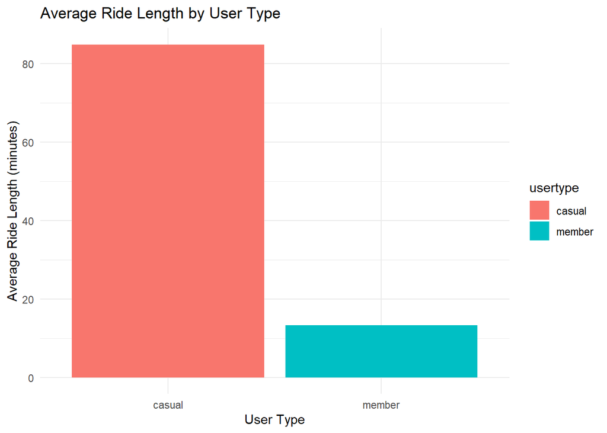

```r
final_trips_groupby1 %>%
  ggplot(aes(x = usertype, y = avg_ride, fill = usertype)) + geom_col() +
  labs(title = "Average Ride Length by User Type",
       x = "User Type",
       y = "Average Ride Length (minutes)") +
  theme_minimal()
```

#### 5.2 Number of Rides by User Type

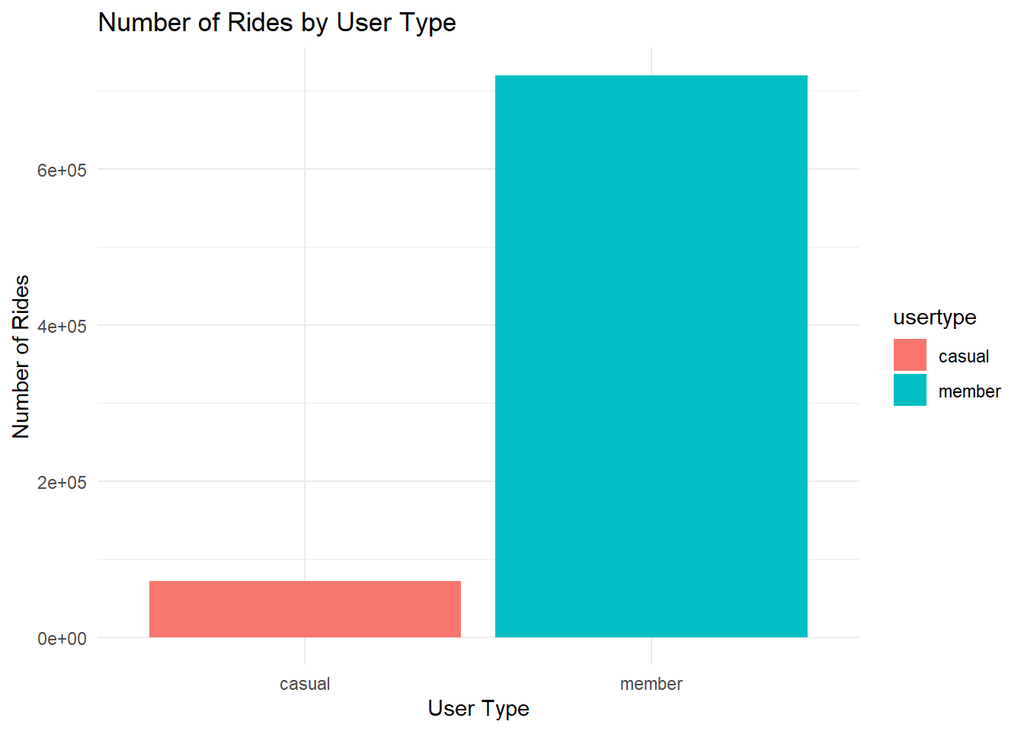

```r
final_trips_groupby1 %>%
  ggplot(aes(x = usertype, y = rides, fill = usertype)) + geom_col() +
  labs(title = "Number of Rides by User Type",
       x = "User Type",
       y = "Number of Rides") +
  theme_minimal()
```

#### 5.3 Average Ride Length by Day of Week

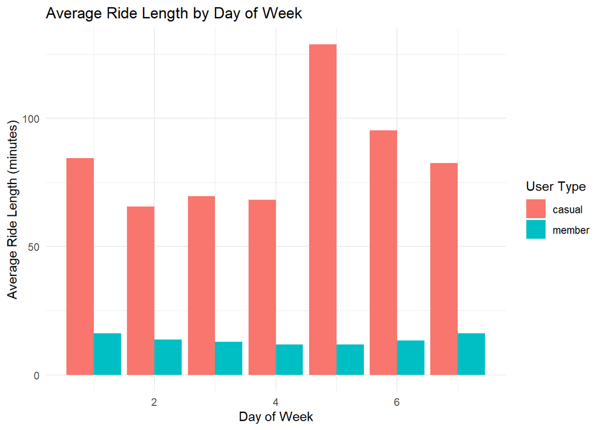

```r
final_trips_groupby2 %>%
  ggplot(aes(x = day_of_week, y = avg_ride, fill = usertype)) +
  geom_col(position = "dodge") +
  labs(title = "Average Ride Length by Day of Week",
       x = "Day of Week",
       y = "Average Ride Length (minutes)",
       fill = "User Type") +
  theme_minimal()
```

#### 5.4 Number of Rides by Day of Week

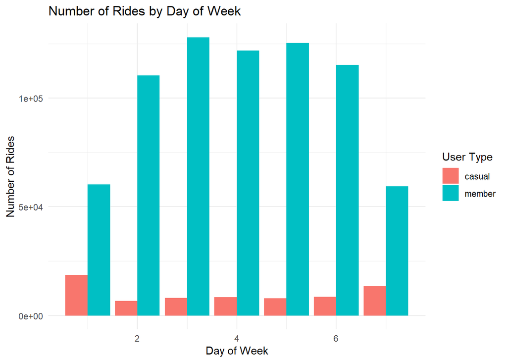

```r
final_trips_groupby2 %>%
  ggplot(aes(x = day_of_week, y = rides, fill = usertype)) +
  geom_col(position = "dodge") +
  labs(title = "Number of Rides by Day of Week",
       x = "Day of Week",
       y = "Number of Rides",
       fill = "User Type") +
  theme_minimal()
```

#### 5.5 Number of Rides by Hour of Day

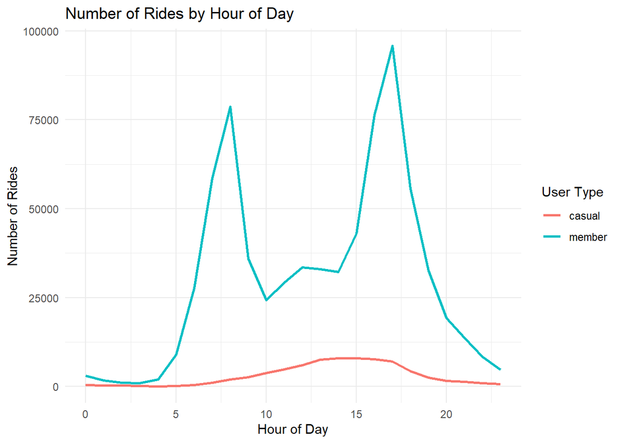

```r
final_trips %>%
  mutate(hour = hour(start_time)) %>%
  group_by(usertype, hour) %>%
  summarize(rides = n()) %>%
  ggplot(aes(x = hour, y = rides, color = usertype)) +
  geom_line(linewidth = 1) +
  labs(
    title = "Number of Rides by Hour of Day",
    x = "Hour of Day",
    y = "Number of Rides",
    color = "User Type"
  ) +
  theme_minimal()
```

### 6. Act

#### 6.1 Conclusion

Based on the analysis and visualizations, clear behavioral differences were identified between Cyclistic members and casual riders. Members tend to take shorter and more consistent rides, primarily during weekdays and peak commuting hours, indicating that they mainly use the service for transportation and daily commuting. In contrast, casual riders generally take longer rides, show greater variability in ride duration, and are more active during weekends, suggesting leisure-based usage of the bike-share service.

These insights highlight a strong opportunity for Cyclistic to convert casual riders into annual members by aligning marketing strategies with their usage patterns and motivations.

#### 6.1 Recommendations

- **Target Weekend Casual Riders with Membership Promotions** Since casual riders are more active on weekends and take longer rides, Cyclistic should launch weekend-focused digital campaigns offering limited-time discounts or trial memberships. This strategy can encourage leisure riders to consider the cost benefits of annual membership.
- **Promote Membership Value Through Ride Cost Comparison** Marketing messages should emphasize how frequent or long casual rides can become more cost-effective with an annual membership. Highlighting potential savings can directly address the financial motivations of casual riders.
- **Use Digital Media to Reach Casual Riders During Peak Leisure Hours** Cyclistic should leverage social media and in-app notifications during weekends and afternoon hours, when casual riders are most active. Personalized messaging during these periods can increase engagement and improve conversion rates.